### Python coding by Gracieli Scremin

# Project Description

Objective - Preliminary Data Analysis. Explore the dataset and practice extracting basic observations about the data. The idea is for you to get comfortable working in Python.

You are expected to do the following :

1. Come up with a customer profile (characteristics of a customer) of the different products
2. Perform uni-variate and multi-variate analyses
3. Generate a set of insights and recommendations that will help the company in targeting new customers

Context - The data is for customers of the treadmill product(s) of a retail store called Cardio Good Fitness. It contains the following variables

- Product - the model no. of the treadmill
- Age - in no of years, of the customer
- Gender - of the customer
- Education - in no. of years, of the customer
- Marital Status - of the customer
- Usage - Avg. # times the customer wants to use the treadmill every week
- Fitness - Self rated fitness score of the customer (5 - very fit, 1 - very unfit)
- Income - of the customer
- Miles- expected to run

Explore the dataset to identify differences between customers of each product. You can also explore relationships between the different attributes of customers. You can approach it from any other line of questioning that you feel could be relevant for the business.

# Minimum Steps for exploration:

- Importing the dataset into Python & understanding the structure of the dataset
- Basic summary of data and graphical exploration
- Observations from the dataset

# Best Practices for Notebook :

The notebook should be well-documented, with inline comments explaining the functionality of code and markdown cells containing comments on the observations and insights. The notebook should be run from start to finish in a sequential manner before submission. It is preferable to remove all warnings and errors before submission. The notebook should be submitted as an HTML file (.html) and NOT as a notebook file (.ipynb)

# Best Practices for Presentation :

The presentation should be made keeping in mind that the audience will be a business leader like CMO, COO, CFO, or CEO. The key points in the presentation should be the following business overview of the problem and solution approach key findings and insights which can drive business decisions model overview and performance summary business recommendations Focus on explaining the takeaways in an easy-to-understand manner. Inclusion of the potential benefits of implementing the solution will give you the edge. Copying and pasting from the notebook is not a good idea, and it is better to avoid showing codes unless they are the focal point of your presentation. The presentation should be submitted as a PDF file (.pdf) and NOT as a .pptx file. A presentation template has been provided for reference.

# Submission Guidelines :

There are two parts to the submission: A well commented Jupyter notebook [format - .html] A presentation as you would present to the top management/business leaders [format - .pdf] Any assignment found copied/ plagiarized with other groups will not be graded and awarded zero marks Please ensure timely submission as any submission post-deadline will not be accepted for evaluation Submission will not be evaluated if, it is submitted post-deadline, or, more than 2 files are submitted Happy Learning!!

### Importing the necessary libraries - pandas, numpy, seaborn, matplotlib.pyplot:

```python
# Library to suppress warnings or deprecation notes
import warnings
warnings.filterwarnings('ignore')
```

```python
# Libraries to help with reading and manipulating data
import numpy as np
import pandas as pd
import matplotlib.pyplot as plt

# Libraries to help with data visualization
import seaborn as sns
%matplotlib inline
```

### Loading the dataset

```python
data=pd.read_csv('CardioGoodFitness.csv')
```

### Looking at the first few rows of the dataset

```python
data.head()
```

|  | Product | Age | Gender | Education | MaritalStatus | Usage | Fitness | Income | Miles |
| --- | --- | --- | --- | --- | --- | --- | --- | --- | --- |
| 0 | TM195 | 18 | Male | 14 | Single | 3 | 4 | 29562 | 112 |
| 1 | TM195 | 19 | Male | 15 | Single | 2 | 3 | 31836 | 75 |
| 2 | TM195 | 19 | Female | 14 | Partnered | 4 | 3 | 30699 | 66 |
| 3 | TM195 | 19 | Male | 12 | Single | 3 | 3 | 32973 | 85 |
| 4 | TM195 | 20 | Male | 13 | Partnered | 4 | 2 | 35247 | 47 |

### Checking shape (total rows and columns) of dataset

```python
data.shape
```

```
(180, 9)
```

### Copying dataset in order to run analyses while maintaining original intact

```python
df = data.copy()
```

### Checking first rows and shape to make sure copy was successful

```python
df.head()
```

|  | Product | Age | Gender | Education | MaritalStatus | Usage | Fitness | Income | Miles |
| --- | --- | --- | --- | --- | --- | --- | --- | --- | --- |
| 0 | TM195 | 18 | Male | 14 | Single | 3 | 4 | 29562 | 112 |
| 1 | TM195 | 19 | Male | 15 | Single | 2 | 3 | 31836 | 75 |
| 2 | TM195 | 19 | Female | 14 | Partnered | 4 | 3 | 30699 | 66 |
| 3 | TM195 | 19 | Male | 12 | Single | 3 | 3 | 32973 | 85 |
| 4 | TM195 | 20 | Male | 13 | Partnered | 4 | 2 | 35247 | 47 |

```python
df.shape
```

```
(180, 9)
```

### Checking column names, count and dtypes

```python
df.info()
```

```
<class 'pandas.core.frame.DataFrame'>
RangeIndex: 180 entries, 0 to 179
Data columns (total 9 columns):
 #   Column         Non-Null Count  Dtype
---  ------         --------------  -----
 0   Product        180 non-null    object
 1   Age            180 non-null    int64
 2   Gender         180 non-null    object
 3   Education      180 non-null    int64
 4   MaritalStatus  180 non-null    object
 5   Usage          180 non-null    int64
 6   Fitness        180 non-null    int64
 7   Income         180 non-null    int64
 8   Miles          180 non-null    int64
dtypes: int64(6), object(3)
memory usage: 12.8+ KB
```

*Observations*

- All columns have 180 observations which seems to indicate there are no missing values but we will check on this below
- There are three columns coded as "object" indicating qualitative variables: Product, Gender, MaritalStatus. These will be converted from "object" to "category" type in order to reduce the data space required to store the dataframe
- Age, Education, Usage, Fitness, Income, and Miles are listed as quantitative variables/features and their values categorized as intergers in Python.

```python
# checking for any missing values
df.isnull().sum()
```

```
Product          0
Age              0
Gender           0
Education        0
MaritalStatus    0
Usage            0
Fitness          0
Income           0
Miles            0
dtype: int64
```

No missing values

### Changing "object" data type to "category" for Product, Gender, MaritalStatus

```python
df['Product'] = df.Product.astype('category')
df['Gender'] = df.Gender.astype('category')
df['MaritalStatus'] = df.MaritalStatus.astype('category')
```

### Creating Education Level categories

As an ordinal variable, education can be treated in analysis as categorical. As such we break it into the different categories below.

```python
df.Education.describe()
```

```
count    180.000000
mean      15.572222
std        1.617055
min       12.000000
25%       14.000000
50%       16.000000
75%       16.000000
max       21.000000
Name: Education, dtype: float64
```

```python
# The minimum number of years of Education for this dataset is 12
# so we begin the classification into different educational categories
# with that number.
conditions_educ = [(df.Education == 12),
             (df.Education > 12) & (df.Education <= 15),
             (df.Education == 16),
             (df.Education > 16)]
```

```python
values_educ = ['High_School', 'Some_college', 'College', 'Graduate_School']
```

```python
df['Education_Level'] = np.select(conditions_educ, values_educ)
```

```python
df['Education_Level'] = df.Education_Level.astype('category')
```

### Creating Age Group categories

```python
# Looking at values distribution of Age variable
df.Age.describe()
```

```
count    180.000000
mean      28.788889
std        6.943498
min       18.000000
25%       24.000000
50%       26.000000
75%       33.000000
max       50.000000
Name: Age, dtype: float64
```

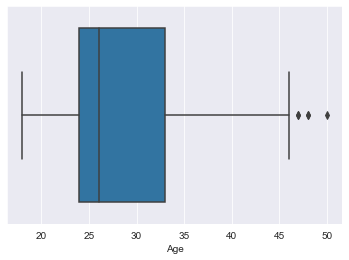

```python
#Visualizing Age distribution
sns.boxplot(df.Age);
```

```python
#Function to calculate IQR
def IQR(feature):
    return feature.quantile(0.75) - feature.quantile(0.25)
```

```python
IQR(df.Age)
```

```
9.0
```

```python
#Right whisker value
df.Age.quantile(0.75) + (1.5 * IQR(df.Age))
```

```
46.5
```

```python
#creating Age group categories based on distribution breakdown
conditions_age = [(df.Age >= 18) & (df.Age < 24),
             (df.Age >= 24) & (df.Age < 26),
             (df.Age >= 26) & (df.Age < 33),
             (df.Age >= 33) & (df.Age < 47),
             (df.Age >= 47)]
```

```python
values_age = ['18 - 23', '24 - 25', '26 - 32', '33 - 46', '47 and older']
```

```python
df['Age_groups'] = np.select(conditions_age, values_age)
```

```python
df['Age_groups'] = df.Age_groups.astype('category')
```

```python
df.Age_groups.value_counts()
```

```
26 - 32         51
33 - 46         45
18 - 23         42
24 - 25         37
47 and older     5
Name: Age_groups, dtype: int64
```

### Checking change of dtypes

```python
df.info()
```

```
<class 'pandas.core.frame.DataFrame'>
RangeIndex: 180 entries, 0 to 179
Data columns (total 11 columns):
 #   Column           Non-Null Count  Dtype
---  ------           --------------  -----
 0   Product          180 non-null    category
 1   Age              180 non-null    int64
 2   Gender           180 non-null    category
 3   Education        180 non-null    int64
 4   MaritalStatus    180 non-null    category
 5   Usage            180 non-null    int64
 6   Fitness          180 non-null    int64
 7   Income           180 non-null    int64
 8   Miles            180 non-null    int64
 9   Education_Level  180 non-null    category
 10  Age_groups       180 non-null    category
dtypes: category(5), int64(6)
memory usage: 10.1 KB
```

### A quick summary of the data, including categorical variables

```python
df.describe(include='all')
```

|  | Product | Age | Gender | Education | MaritalStatus | Usage | Fitness | Income | Miles | Education_Level | Age_groups |
| --- | --- | --- | --- | --- | --- | --- | --- | --- | --- | --- | --- |
| count | 180 | 180.000000 | 180 | 180.000000 | 180 | 180.000000 | 180.000000 | 180.000000 | 180.000000 | 180 | 180 |
| unique | 3 | NaN | 2 | NaN | 2 | NaN | NaN | NaN | NaN | 4 | 5 |
| top | TM195 | NaN | Male | NaN | Partnered | NaN | NaN | NaN | NaN | College | 26 - 32 |
| freq | 80 | NaN | 104 | NaN | 107 | NaN | NaN | NaN | NaN | 85 | 51 |
| mean | NaN | 28.788889 | NaN | 15.572222 | NaN | 3.455556 | 3.311111 | 53719.577778 | 103.194444 | NaN | NaN |
| std | NaN | 6.943498 | NaN | 1.617055 | NaN | 1.084797 | 0.958869 | 16506.684226 | 51.863605 | NaN | NaN |
| min | NaN | 18.000000 | NaN | 12.000000 | NaN | 2.000000 | 1.000000 | 29562.000000 | 21.000000 | NaN | NaN |
| 25% | NaN | 24.000000 | NaN | 14.000000 | NaN | 3.000000 | 3.000000 | 44058.750000 | 66.000000 | NaN | NaN |
| 50% | NaN | 26.000000 | NaN | 16.000000 | NaN | 3.000000 | 3.000000 | 50596.500000 | 94.000000 | NaN | NaN |
| 75% | NaN | 33.000000 | NaN | 16.000000 | NaN | 4.000000 | 4.000000 | 58668.000000 | 114.750000 | NaN | NaN |
| max | NaN | 50.000000 | NaN | 21.000000 | NaN | 7.000000 | 5.000000 | 104581.000000 | 360.000000 | NaN | NaN |

**Observations**

- Corroborating with observations above, the most popular product among customers in this dataset is TM195. Most of the customers are male and have partners
- Mean age for customers is 28.78. Median age is 26 years which indicates age distribution is positively or right-skewed. We also observe a wide range of ages for customers: youngest age 18 and oldest, 50, though 50% of customers fall within the 24 to 33 age range.
- In terms of education/education level, most of the customers have a post High School education, with mid range 50% of them falling between the some college (14 years of education) to college (16 years of education) education level range.
- Usage, the average number of times per week customer wants to use treadmill, has a mean of 3.45, higher than the median of 3. Mid range 50% of customers indicated they would like to use treadmill between 3 and 4 times a week.
- Fitness, self-rated fitness level with 1 being very unfit and 5 being very fit, shows for this dataset that mid range 50% of customers rate themselves between 3 and 4. Mean (3.31) is higher than median (3.0) indicating a positively skewed distribution for the self-rated fitness distribution variable.
- In terms of yearly income, mean and median are close: '53,719.57 USD' and '50,596.50 USD' respectively. Mid range of 50% of customers fall within the income range '44,058.75' to '58,668.00' USD
- Miles expected to run vary widely, from a minimum of 21 miles to a max of 360 miles (presumably per week). The mean is greater than the median value indicating a right-skewed distribution.

# Exploratory Data Analysis

## Exploring numerical variables through Univariate Analysis

```python
# Function below helps to create a boxplot and histogram for any input numerical
# variable. It takes the numerical column as the input and returns the boxplots
# and histograms for the variable.

def histogram_boxplot(feature, figsize=(15,10), bins = None):
    """ Boxplot and histogram combined
    feature: 1-d feature array
    figsize: size of fig (default (9,8))
    bins: number of bins (default None / auto)
    """
    f2, (ax_box2, ax_hist2) = plt.subplots(nrows = 2, # Number of rows of the subplot grid= 2
                                           sharex = True, # x-axis will be shared among all subplots
                                           gridspec_kw = {"height_ratios": (.25, .75)},
                                           figsize = figsize
                                           ) # creating the 2 subplots
    sns.boxplot(feature, ax=ax_box2, showmeans=True, color='green') # boxplot will be created and a star will indicate the mean value of the column
    sns.distplot(feature, kde=F, ax=ax_hist2, bins=bins) if bins else sns.distplot(feature, kde=False, ax=ax_hist2) # For histogram
    ax_hist2.axvline(np.mean(feature), color='g', linestyle='--') # Add mean to the histogram
    ax_hist2.axvline(np.median(feature), color='black', linestyle='-') # Add median to the histogram
```

### Observations on Usage

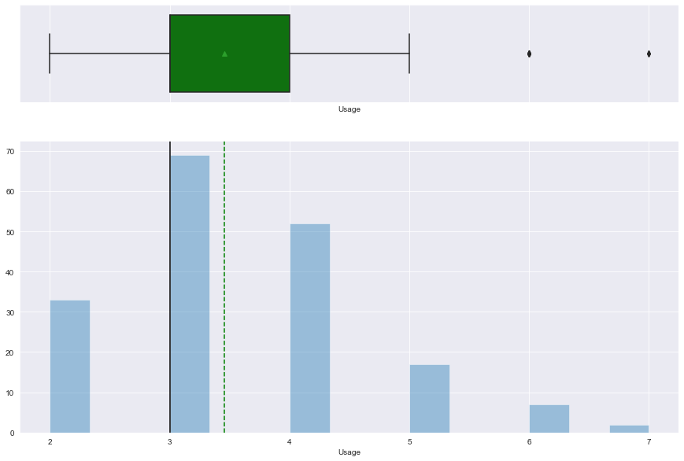

```python
histogram_boxplot(df.Usage)
```

```python
IQR(df.Usage)
```

```
1.0
```

**Observations**

- Usage, the average number of times per week customer wants to use treadmill, has a mean value of 3.45, higher than the median of 3 days reflected by the presence of high value outliers.
- Distribution is right-skewed
- Mid range 50% of customers indicated they would like to use treadmill between 3 and 4 times a week.

### Observations on Fitness

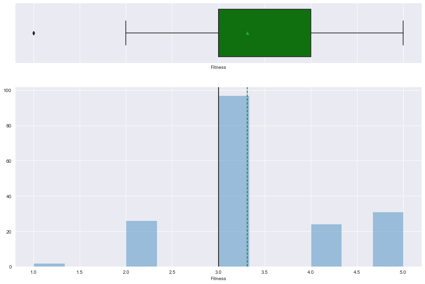

```python
histogram_boxplot(df.Fitness)
```

```python
IQR(df.Fitness)
```

```
1.0
```

**Observations**

### Observations on Income

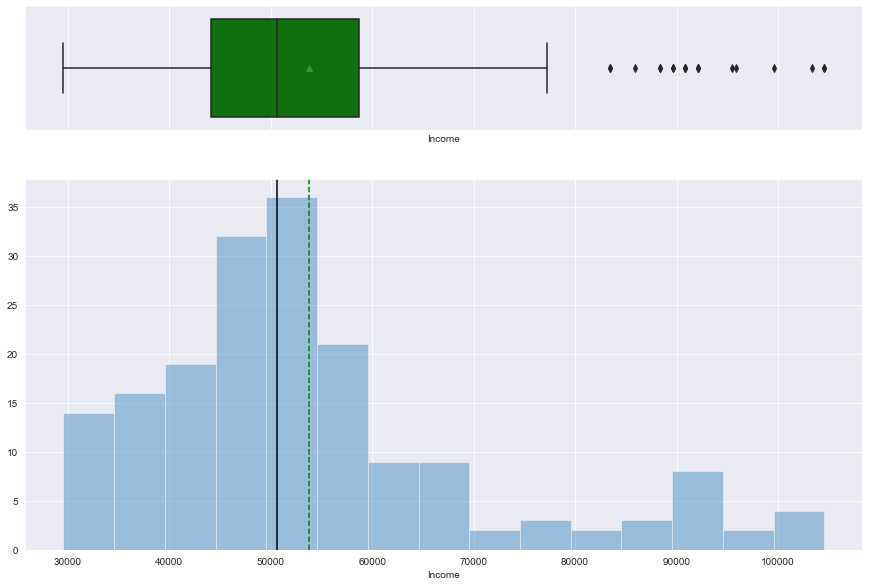

```python
histogram_boxplot(df.Income)
```

```python
IQR(df.Income)
```

```
14609.25
```

```python
df.Income.quantile(0.75) + (1.5*IQR(df.Income))
```

```
80581.875
```

**Observations**

- In terms of yearly income, mean and median are close: '53,719.57 USD' and '50,596.50 USD' respectively. Mid 50% of customers fall within the income range '44,058.75' to '58,668.00' USD.
- We see the presence of high value outliers in this dataset: values greater than '80,581.88 USD' (Q3+(1.5*IQR))

### Observations on Miles

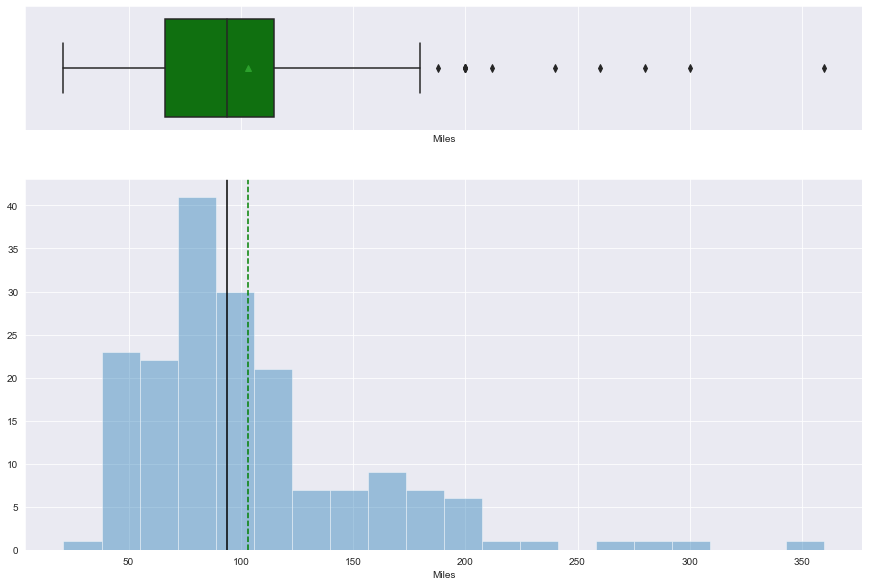

```python
histogram_boxplot(df.Miles)
```

```python
IQR(df.Miles)
```

```
48.75
```

```python
df.Miles.quantile(0.75) + (1.5*IQR(df.Miles))
```

```
187.875
```

**Observations**

- Miles expected to run vary widely, from a minimum of 21 miles to a max of 360 miles (presumably per week).
- The mean (103.19 miles) is greater than the median value (94 miles) indicating a right-skewed distribution - presence of high value outliers (in this case, values greater than 187.88 miles)

### Observations on Age

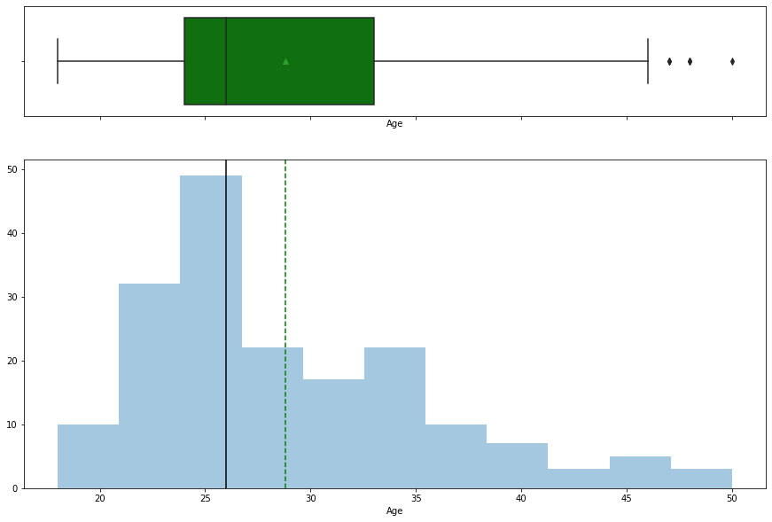

```python
histogram_boxplot(df.Age)
```

```python
IQR(df.Age)
```

```
9.0
```

```python
df.Age.quantile(0.75) + (1.5*IQR(df.Age))
```

```
46.5
```

**Observations**

### Visually exploring categorical variables

```python
# Function to create barplots that indicate percentage for each category.
def bar_perc(plot, feature):
    '''
    plot
    feature: 1-d categorical feature array
    '''
    total = len(feature) # length of the column
    for p in ax.patches:
        percentage = '{:.1f}%'.format(100 * p.get_height()/total) # percentage of each class of the category
        x = p.get_x() + p.get_width() / 2 - 0.05 # width of the plot
        y = p.get_y() + p.get_height()           # hieght of the plot
        ax.annotate(percentage, (x, y), size = 12) # annotate the percantage
```

### Observations on Product

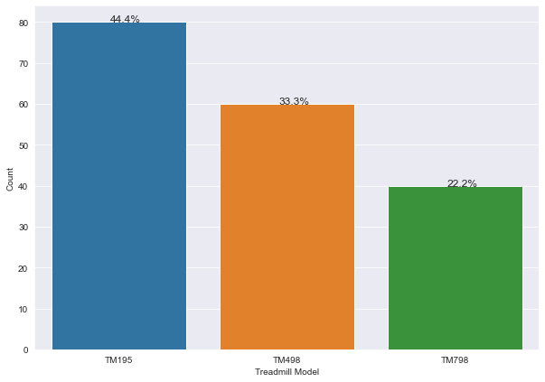

```python
plt.figure(figsize=(10,7))
ax = sns.countplot(df.Product)
plt.xlabel('Treadmill Model')
plt.ylabel('Count')
bar_perc(ax,df.Product)
```

**Observations**

- The most popular treadmill model is TM195, followed by TM498

### Observations on Gender

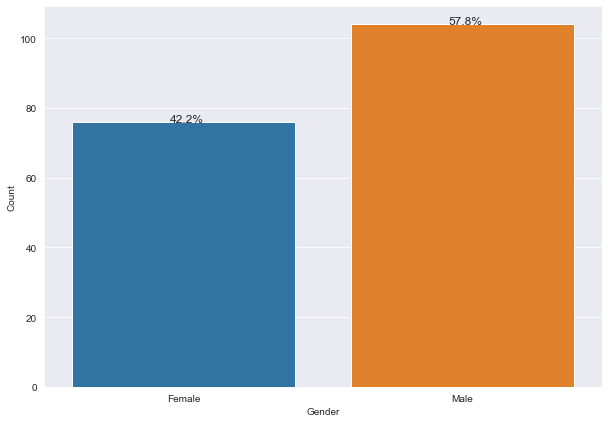

```python
plt.figure(figsize=(10,7))
ax = sns.countplot(df.Gender)
plt.xlabel('Gender')
plt.ylabel('Count')
bar_perc(ax,df.Gender)
```

**Observations**

- A majority of customers, 57.8%, are male

### Observations on Education

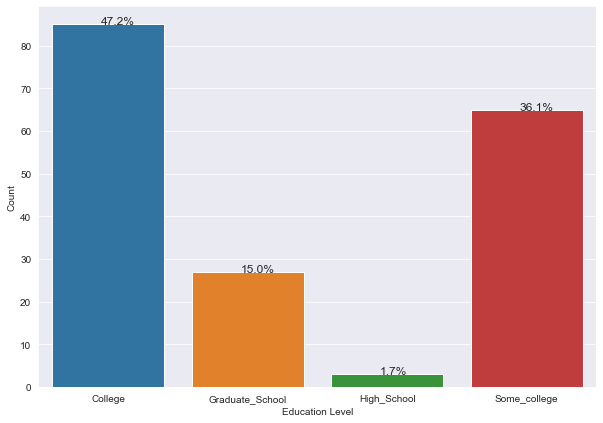

```python
plt.figure(figsize=(10,7))
ax = sns.countplot(df.Education_Level)
plt.xlabel('Education Level')
plt.ylabel('Count')
bar_perc(ax,df.Education_Level)
```

**Observations**

- Most customers have education levels higher than High School - 83.3% falling into Some College/College categories

### Observations on Marital Status

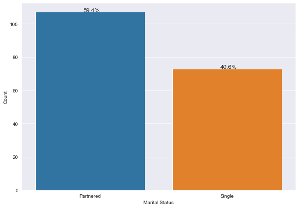

```python
plt.figure(figsize=(10,7))
ax = sns.countplot(df.MaritalStatus)
plt.xlabel('Marital Status')
plt.ylabel('Count')
bar_perc(ax,df.MaritalStatus)
```

-**Observations**

- Nearly 60% of customers' marital status are "partnered"

### Observations on Age Group

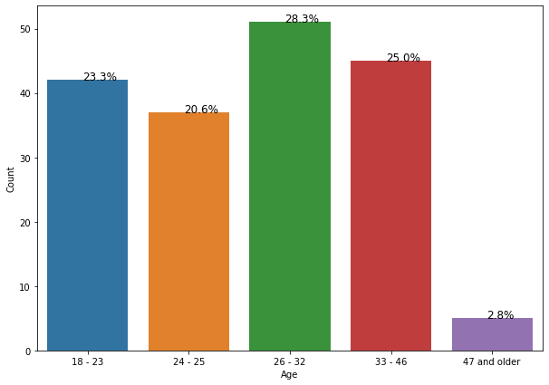

```python
plt.figure(figsize=(10,7))
ax = sns.countplot(df.Age_groups)
plt.xlabel('Age')
plt.ylabel('Count')
bar_perc(ax,df.Age_groups)
```

**Observations**

- Most customers are in their 20s to mid 30s

## Bivariate Analysis

**Plot bivariate charts between variables to understand their interaction with each other.**

**Correlation**

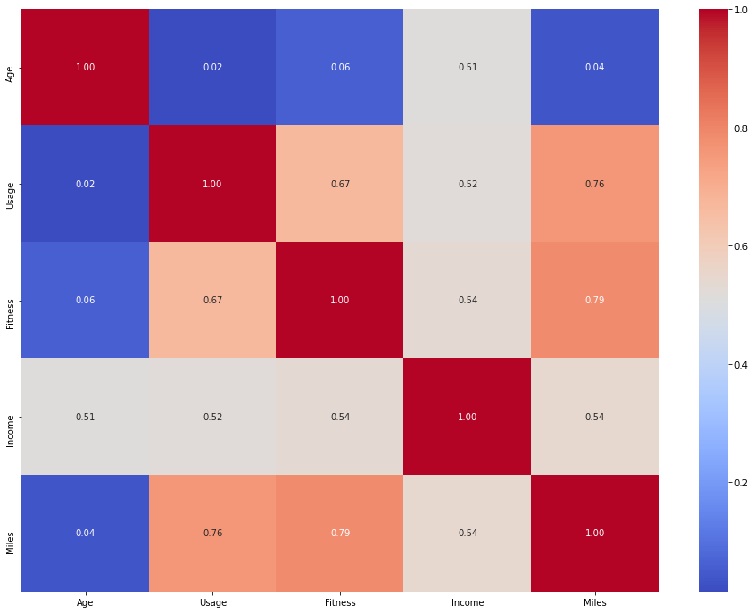

```python
# Check for correlation among numerical variables
num_var = ['Age','Usage','Fitness','Income','Miles']

corr = df[num_var].corr()

# plot the heatmap
plt.figure(figsize=(16,12))
sns.heatmap(corr, annot=True,cmap='coolwarm',
        fmt=".2f",
        xticklabels=corr.columns,
        yticklabels=corr.columns);
```

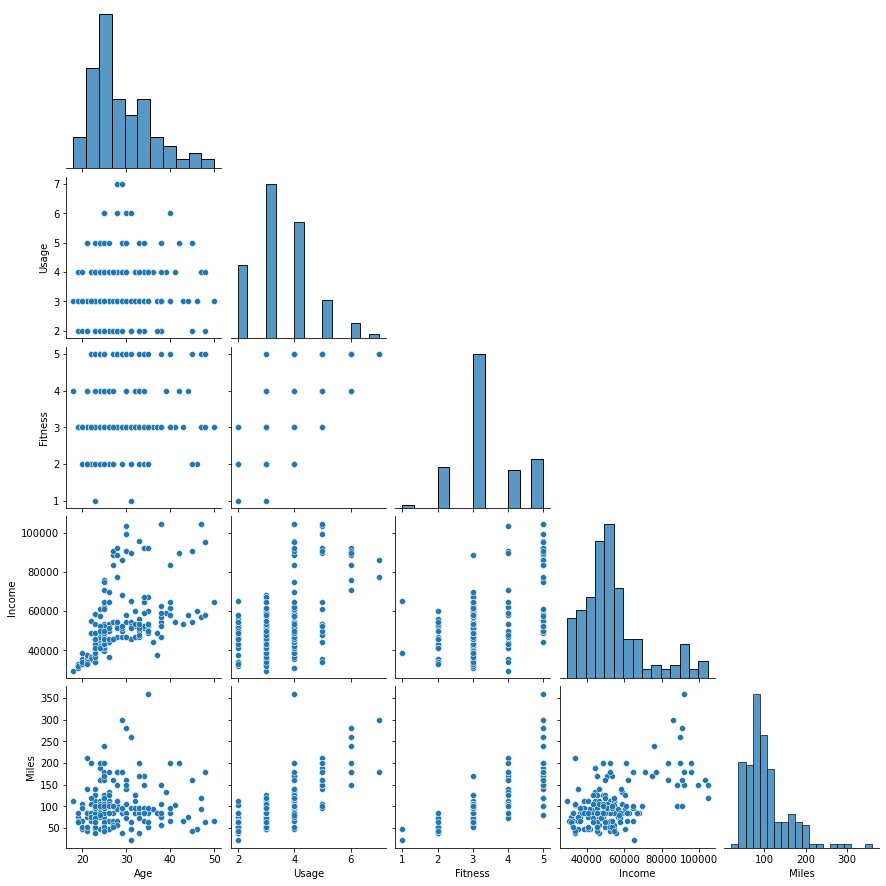

```python
sns.pairplot(df[num_var], corner=True)
plt.show()
```

**Observations**

- As one would expect, data shows positive correlation between Miles (expected miles run per week) and Usage (average number of times per week customer wants to use treadmill), 0.76
- We also observe a positive correlation (0.79) between expected miles run per week and self-rated fitness level
- Age and Fitness, Age and Miles, and Age and Usage are not observed to be strongly correlated
- Moderate positive correlations observed between Income and Usage, Income and Fitness, and Income and Miles
- Important to note that none of the relationships described above imply causality

### Exploring customer characteristics

```
TM195    80
TM498    60
TM798    40
Name: Product, dtype: int64
```

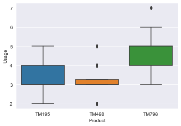

```python
# Relationship between treadmill model purchased and customer-rated expected Usage

sns.boxplot(df.Product, df.Usage);
df.Product.value_counts()
```

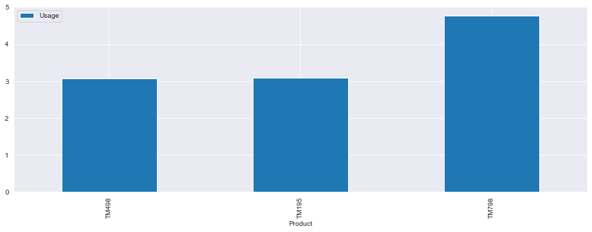

```python
df.groupby(by=['Product'])['Usage'].mean().reset_index().sort_values(['Usage'], ascending=True).plot(x='Product', y='Usage', kind='bar', figsize=(15,5))
plt.show()
```

**Observations**

- Customers who purchased TM195 rated their usage between a minimum of 2 days and a maximum of 5 days per week, with 50% middle of the data falling between 3 and 4 day Usage
- For TM498 customers the range of rated Usage was narrower, around 3 days per week; with a few outliers
- Usage ratings were higher among TM798 customers, ranging between 3 and 6 with a few 7 days per week outliers

```
3    97
5    31
2    26
4    24
1     2
Name: Fitness, dtype: int64
```

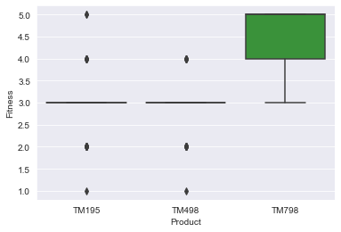

```python
# Relationship between treadmill model purchased and customer-rated fitness

sns.boxplot(df.Product, df.Fitness);
df.Fitness.value_counts()
```

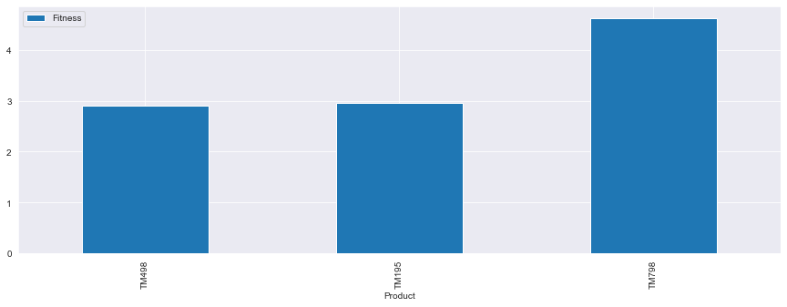

```python
df.groupby(by=['Product'])['Fitness'].mean().reset_index().sort_values(['Fitness'], ascending=True).plot(x='Product', y='Fitness', kind='bar', figsize=(15,5))
plt.show()
```

**Observations**

- Mean Fitness rating for TM195 and TM498 customers is approximately 3, distribution for both groups has a few outliers
- Mean Fitness rating for TM798 customers is over 4.5, with 50% of the middle values of the distribution falling between 4 and 5 Fitness rating

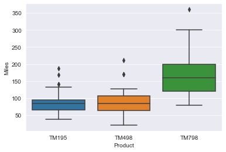

```python
# Relationship between treadmill model purchased and Miles customer expected to run

sns.boxplot(df.Product, df.Miles);
```

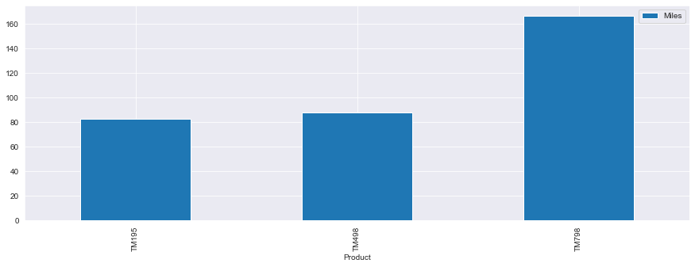

```python
df.groupby(by=['Product'])['Miles'].mean().reset_index().sort_values(['Miles'], ascending=True).plot(x='Product', y='Miles', kind='bar', figsize=(15,5))
plt.show()
```

**Observations**

- Following the same trend we observe with respect to Product Model and Usage and Product Model and Fitness, TM798 customers expected to run more miles in their treadmill than TM498 and TM195 customers
- Though with slightly lower mean, TM195 rated their expected miles similarly to TM498 customers; middle 50% of these customers rating expected milage between 65 and 100

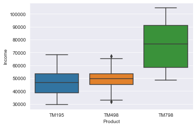

```python
# Relationship between treadmill model purchased and Income

sns.boxplot(df.Product, df.Income);
```

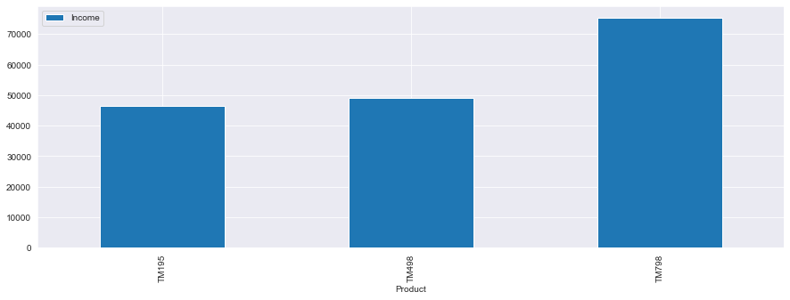

```python
df.groupby(by=['Product'])['Income'].mean().reset_index().sort_values(['Income'], ascending=True).plot(x='Product', y='Income', kind='bar', figsize=(15,5))
plt.show()
```

```python
df.groupby(by=['Product'])['Income'].mean().reset_index()
```

|  | Product | Income |
| --- | --- | --- |
| 0 | TM195 | 46418.025 |
| 1 | TM498 | 48973.650 |
| 2 | TM798 | 75441.575 |

**Observations**

- We observe TM798 customers' Income as higher on average than both TM195 and TM498 customers, ranging between approximately 50,000 and 100,000 USD a year; with 50% middle range between approx. 60 and 90K
- Income distribution ranges more widely for TM195 customers than for TM498; mean income for TM195 customers is slightly lower: 46,418.02 compared to 48,973.65

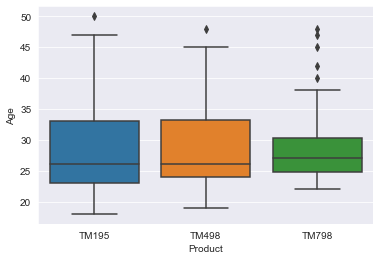

```python
# Relationship between treadmill model purchased and customer Age

sns.boxplot(df.Product, df.Age);
```

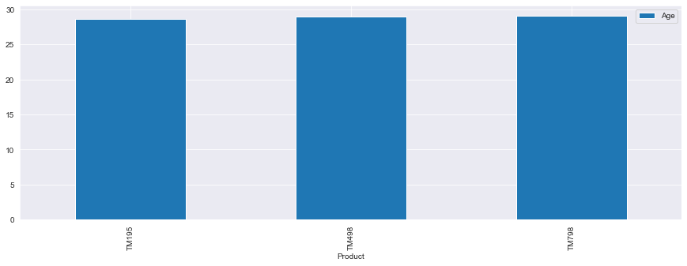

```python
df.groupby(by=['Product'])['Age'].mean().reset_index().sort_values(['Age'], ascending=True).plot(x='Product', y='Age', kind='bar', figsize=(15,5))
plt.show()
```

**Observations**

### Examining the relationship between Treadmill model (Product) purchased and categorical variables: Gender, Education Level, Marital Status, and Age Group

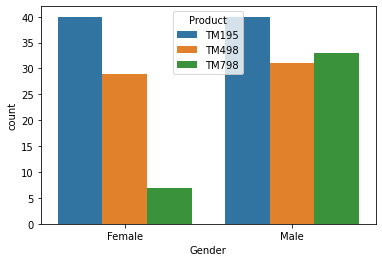

```python
sns.countplot(df.Gender, hue=df.Product);
```

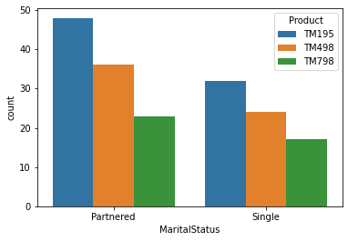

```python
sns.countplot(df.MaritalStatus, hue=df.Product);
```

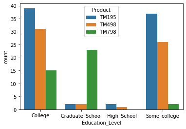

```python
sns.countplot(df.Education_Level, hue=df.Product);
```

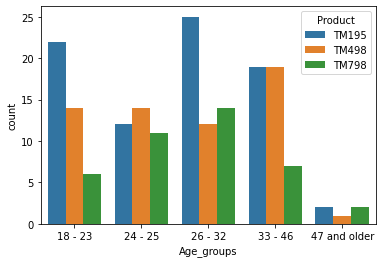

```python
sns.countplot(df.Age_groups, hue=df.Product);
```

**Observations**

- We observe greater number of male TM798 customers
- More of Cardio Good Fitness customers have a partner than who are single across treadmill models
- TM798 customers are more highly educated than both TM195 and TM498 customer groups
- Most TM195 and TM798 customers fall in the 26-32 age group; most TM498 customers fall into the 33-46 age group
- These treadmill customers in general are adults most in their 20s to mid 30s

## Multivariate Analysis

### Examining the relationship between Product (Treadmill Model) and Usage in light of customer Gender, Educational Level, Marital Status, and Age Group

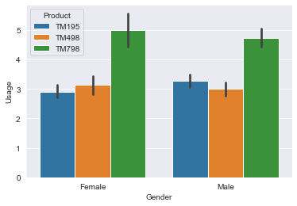

```python
sns.barplot(df.Gender, df.Usage, hue=df.Product);
```

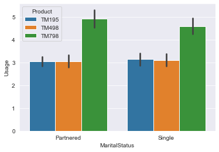

```python
sns.barplot(df.MaritalStatus, df.Usage, hue=df.Product);
```

```
College            85
Some_college       65
Graduate_School    27
High_School         3
Name: Education_Level, dtype: int64
```

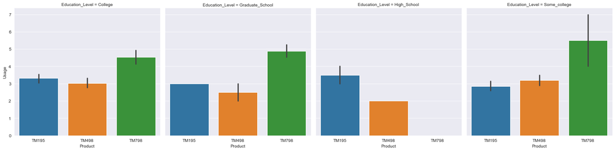

```python
sns.catplot(x='Product', y='Usage',
             col='Education_Level',
             data=df,
             col_wrap=4,
             kind="bar");
df.Education_Level.value_counts()
```

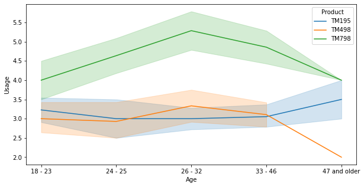

```python
plt.figure(figsize=(10,5))
sns.lineplot(x="Age_groups", y="Usage", ci=95, data=df, hue='Product')
plt.ylabel('Usage')
plt.xlabel('Age')
plt.show()
```

**Observations**

- TM195 and TM498 customer groups are more similar to each other in contrast to TM798 customers in terms of Usage ratings (TM798 customers expressing higher average number of times they want to use treadmill), even when considering gender, marital status, education level, and age differences
- We observe a decline is expected use days per week from the 26 - 32 group to the older age groups among TM798 and TM498 customers
- Lowest levels of usage were rated by TM498 customers from the 47 and older age group
- With only 3 customer counts, it is difficult to draw any conclusions on the relationship between Treadmill/Product model and Usage for customers with High School education level